# How the Netflix Challenge Was Won: Regularization and Matrix Factorization

Alyssa Frazee and Rafael Irizarry

### Recommendation systems

- On October 2006 Netflix offered a challenge to the data science community: improve our recommendation algorithm by 10% and win a million dollars.
- In September 2009 winners were announced

[figure not shown]

### Ratings Data

```r
ratings
```

```
Source: local data frame [21,628,601 x 4]

   userId movieId rating  timestamp
    (int)   (int)  (dbl)      (int)
1       1    2471    3.0 1204927438
2       1   48516    5.0 1204927435
3       2    2571    3.5 1436165433
4       2  112552    5.0 1436165496
5       2  112556    4.0 1436165499
6       3     356    4.0  920587155
7       3    2394    4.0  920586920
8       3    2445    4.0  920586945
9       4      16    4.0 1037740142
10      4      39    4.0 1037740562
..    ...     ...    ...        ...
```

### Ratings Data

```r
ratings %>%
  summarize(n_users = n_distinct(userId),
            n_movies=n_distinct(movieId))
```

```
Source: local data frame [1 x 2]

  n_users n_movies
    (int)    (int)
1  247753    33670
```

### Ratings Distribution

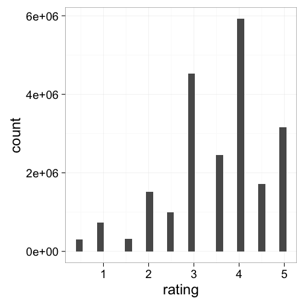

```r
ratings %>% ggplot(aes(rating)) + geom_histogram()
```

### Visualize as a Matrix

| userId | Forrest Gump | Jurassic Park | Pulp Fiction | Shawshank Redemption, The | Silence of the Lambs, The |
| --- | --- | --- | --- | --- | --- |
| 13 | NA | 4 | NA | NA | NA |
| 14 | 5.0 | 5 | 2 | NA | 3.0 |
| 15 | 4.5 | NA | 3 | 5 | 5.0 |
| 16 | NA | 4 | NA | NA | NA |
| 17 | 5.0 | 4 | 2 | 5 | 2.0 |
| 18 | 3.0 | 3 | 4 | 5 | 5.0 |
| 20 | NA | 3 | 3 | NA | 4.5 |

### Many Missing Values

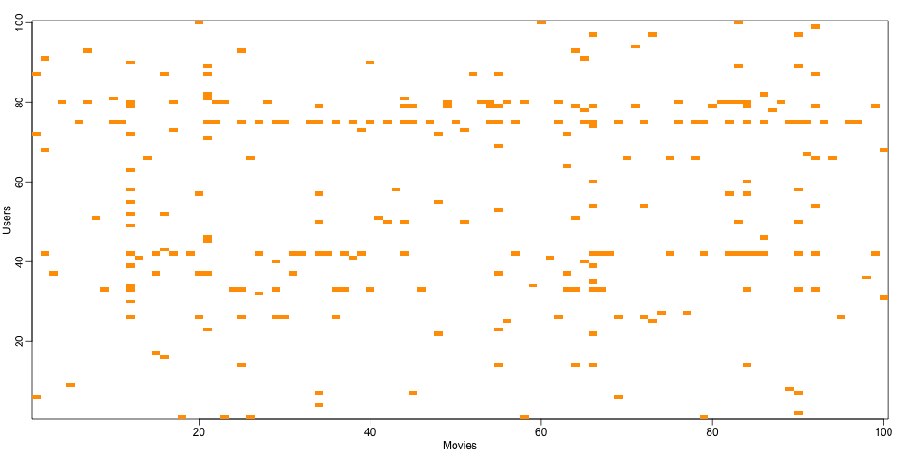

### Number of Ratings per Users, per Movie

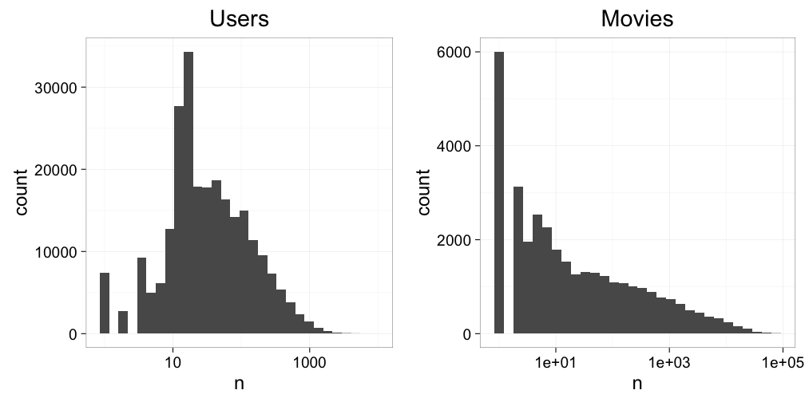

### Split the Data

```r
set.seed(755)
n_test <- round(nrow(ratings) / 10)
test_indices <- sample(1:nrow(ratings), n_test, replace=FALSE)
test <- ratings[test_indices,]
train <- ratings[-test_indices,]
rm(ratings) #to save space
gc() #make sure memory is cleared
```

```
           used  (Mb) gc trigger   (Mb)  max used   (Mb)
Ncells   601554  32.2    1168576   62.5   1168576   62.5
Vcells 56395864 430.3  207811316 1585.5 392263067 2992.8
```

### Loss function and RMSE

If \hat{Y} is our prediction and \( Y \) is the observed rating we minimize:

\[ \mbox{E}(\hat{Y} - Y) \]

In practice we look at the empirical version of this which is the RMSE:

\[ \mbox{RMSE} = \sqrt{\frac{1}{M \times N} \sum_{u=1}^M\sum_{i=1}^N \left(\hat{Y}_{u,i} - Y_{u,i}\right)^2} \]

\( Y_{u,i} \) is the true rating by user \( u \) for movie \( i \)

\( \hat{Y}_{u,i} \) our predicted rating.

### A First Model

\[ Y_{u,i} = \mu + \varepsilon_{u,i} \]

with \( \varepsilon_{u,i} \) independent errors sampled from the same distribution centered at 0.

### RMSE for Naive Model

Estimate:

```r
mu <- mean(train$rating)
mu
```

```
[1] 3.525548
```

RMSE:

```
[1] 1.060378
```

To win the grand prize of $1,000,000: RMSE of about 0.857.

### Modeling Movie Effects

Movies with more than 1000 ratings:

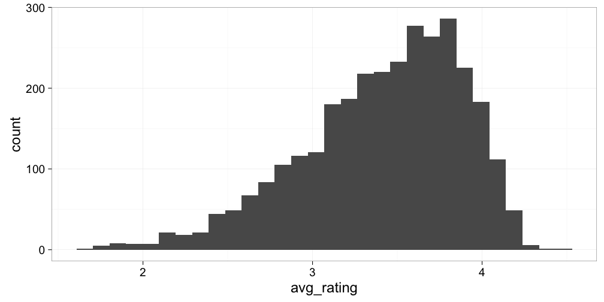

### Modeling Movie Effects

\[ Y_{u,i} = \mu + b_i + \varepsilon_{u,i} \]

In statistics we usually call the $b$s as effects, but in the Netflix challenge papers they refer to them as “bias” thus the \( b \) notation.

The least square estimate \[ \hat{b}_i = Y_{u,i} - \hat{\mu} \]

### Movie Effects

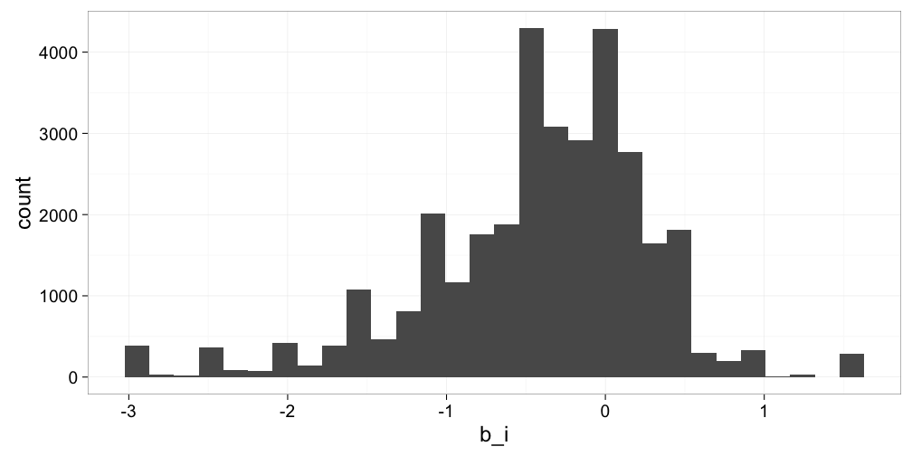

### Improved Prediction

To create predictions:

```r
joined <- test %>%
  left_join(movie_means, by='movieId')
any( is.na(joined$b_i))
```

```
[1] TRUE
```

And deal with movies not in train set:

```r
joined <- replace_na(joined, list(b_i=0))
```

Form: \( Y_{u,i} = \hat{\mu} + \hat{b}_i \)

### Improved Prediction

| method | RMSE |
| --- | --- |
| Just the average | 1.0604 |
| Movie Effect Model | 0.9548 |

### Motivating Regularization

Let's explore where we made big mistakes.

| title | prediction | residual |
| --- | --- | --- |
| Remote Area Medical | 0.5 | -4.5 |
| Willie & Phil | 0.5 | -4.5 |
| The Genius of Marian | 0.5 | -4.5 |
| Kissinger | 5.0 | 4.5 |
| Linda and Abilene | 0.5 | -4.5 |
| Hank: 5 Years from the Brink | 0.5 | -4.5 |
| Pastoral Hide and Seek | 0.5 | -4.5 |
| Passage de Venus | 5.0 | 4.5 |
| King of Texas | 5.0 | 4.5 |
| Shelter Island | 0.5 | -4.5 |

### Top 5 Worst and Best Movies

| title | b_i |
| --- | --- |
| Hellhounds on My Trail | 1.47 |
| Life On A String | 1.47 |
| Hijacking Catastrophe: 9/11, Fear & the Selling of American Empire | 1.47 |
| Fine Madness, A | 1.47 |
| Al otro lado | 1.47 |

| title | b_i |
| --- | --- |
| Besotted | -3.03 |
| Trumpet of the Swan, The | -3.03 |
| Bad Boy | -3.03 |
| Joysticks | -3.03 |
| Allan Quatermain and the Temple of Skulls | -3.03 |

### High Variance Estimates

| title | b_i | n |
| --- | --- | --- |
| Besotted | -3.03 | 2 |
| Trumpet of the Swan, The | -3.03 | 1 |
| Bad Boy | -3.03 | 1 |
| Joysticks | -3.03 | 1 |
| Allan Quatermain and the Temple of Skulls | -3.03 | 1 |

| title | b_i | n |
| --- | --- | --- |
| Hellhounds on My Trail | 1.47 | 2 |
| Life On A String | 1.47 | 1 |
| Hijacking Catastrophe: 9/11, Fear & the Selling of American Empire | 1.47 | 1 |
| Fine Madness, A | 1.47 | 1 |
| Al otro lado | 1.47 | 1 |

### Regularization

How to deal with uncertainty?

Confidence intervals?

In prediction we need one number

### Penalized Least Squares

The equation we now minimize is:

\[ \frac{1}{M \times N} \sum_{u=1}^M \left(Y_{u,i} - \mu - b_i\right)^2 + \lambda \sum_{i=1}^I b_i^2 \]

Using calculus we can actually show that the values of \( b_i \) that minimize this equation are:

\[ \hat{b}_i(\lambda) = \frac{1}{\lambda + n_i} \sum_{u=1}^{n_i} \left(Y_{u,i} - \hat{\mu}\right) \]

### Improvements

| title | b_i | n |
| --- | --- | --- |
| SuperBabies: Baby Geniuses 2 | -2.6 | 188 |
| From Justin to Kelly | -2.5 | 380 |
| Hip Hop Witch, Da | -2.5 | 25 |
| Barbie & Her Sisters in the Great Puppy Adventure | -2.5 | 51 |
| Justin Bieber's Believe | -2.4 | 13 |

| title | b_i | n |
| --- | --- | --- |
| Shawshank Redemption, The | 0.92 | 65806 |
| Can't Change the Meeting Place | 0.90 | 17 |
| Godfather, The | 0.83 | 42264 |
| Usual Suspects, The | 0.79 | 45219 |
| Pardon | 0.78 | 7 |

### RMSE Improves Too

| method | RMSE |
| --- | --- |
| Just the average | 1.0604 |
| Movie Effect Model | 0.9548 |
| Movie Effect Model Lambda=3 | 0.9545 |

### Visualizing Shrinkage

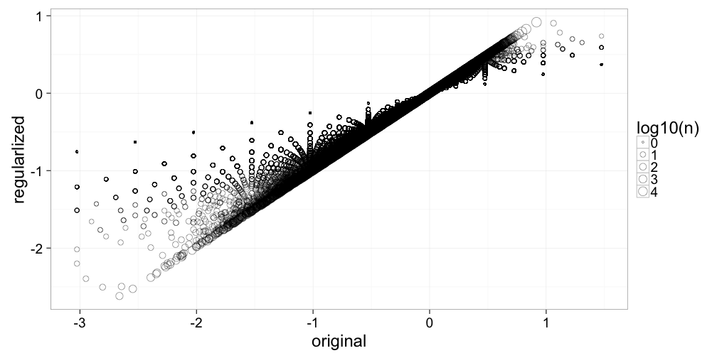

### How to Pick Penalty

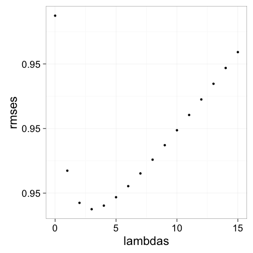

### User effects

User averages for those that rated more than 100:

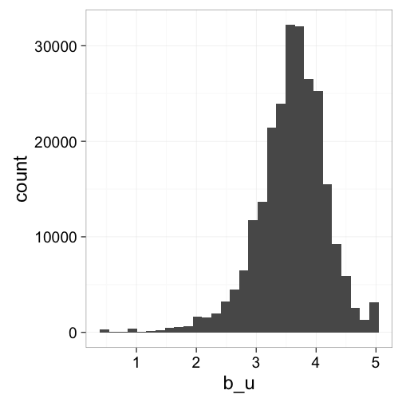

### Model User Effect

\[ Y_{u,i} = \mu + b_i + b_u + \varepsilon_{u,i} \]

where is \( b_u \) a user-specific effect.

Avoid `lm` by averaging:

\[ Y_{u,i} - \hat{\mu} - \hat{b}_i \]

And use regularization:

\[ \hat{b}_u = \frac{1}{\lambda_2 + n_u} \sum_{i=1}^{n_u} (Y_{u,i} - \hat{\mu} - \hat{b}_i) \]

### Improvement

| method | RMSE |
| --- | --- |
| Just the average | 1.0604 |
| Movie Effect Model | 0.9548 |
| Movie Effect Model Lambda=3 | 0.9545 |
| Movie and User Effect Model | 0.8683 |

### Matrix Factorization

Use a smaller set for illustration.

Compute residuals and form matrix: \( r_{u,i} = Y_{u,i} - \hat{\mu} - \hat{b}_i -\hat{b}_u \)

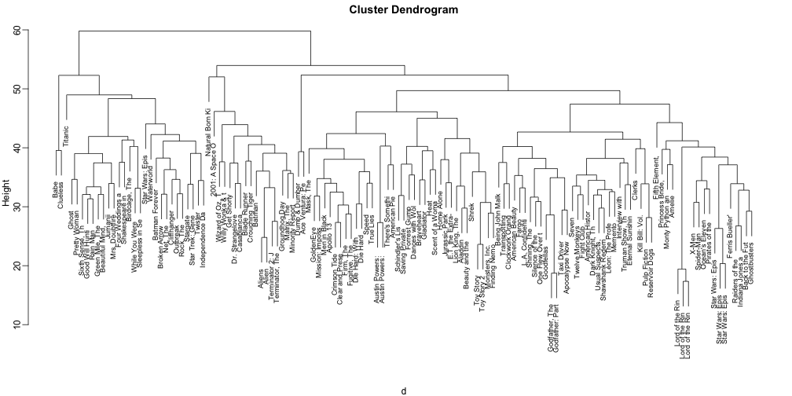

### Moises that correlate

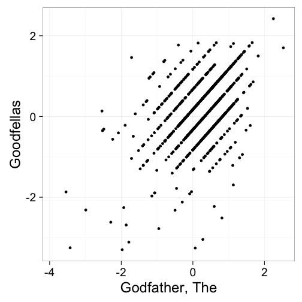

### Moises that correlate

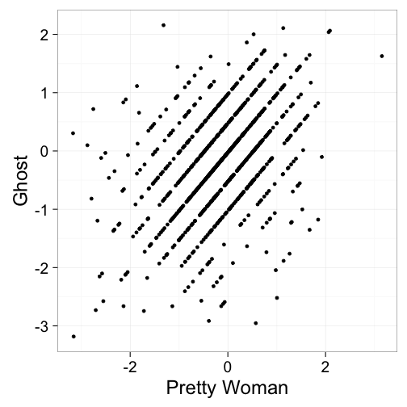

### Negative Correlation

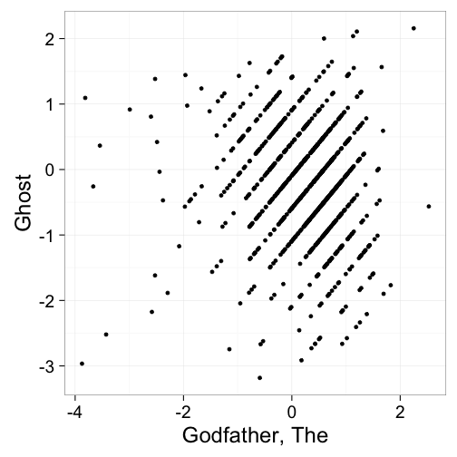

### Factors

| Godfather1 | Godfather2 | Goodfellas | Pretty Woman | Ghost |
| --- | --- | --- | --- | --- |
| 1.81 | 2.15 | 1.81 | -1.76 | -1.81 |
| 1.90 | 1.91 | 1.91 | -2.31 | -1.85 |
| 2.06 | 2.22 | 1.61 | -1.82 | -2.02 |
| 0.33 | 0.00 | -0.09 | -0.07 | 0.29 |
| -0.24 | 0.17 | 0.30 | 0.26 | -0.05 |
| 0.32 | 0.39 | -0.13 | 0.12 | -0.20 |
| 0.36 | -0.10 | -0.01 | 0.23 | -0.34 |
| 0.13 | 0.22 | 0.08 | 0.04 | -0.32 |
| -1.90 | -1.65 | -2.01 | 2.02 | 1.85 |
| -2.35 | -2.23 | -2.25 | 2.23 | 2.01 |
| -2.24 | -1.88 | -1.74 | 1.62 | 2.13 |
| -2.26 | -2.30 | -1.87 | 1.98 | 1.93 |

### Strong Correlation

```r
cor(X)
```

```
             Godfather1 Godfather2 Goodfellas Pretty Woman Ghost
Godfather1         1.00       0.99       0.98        -0.98 -0.99
Godfather2         0.99       1.00       0.99        -0.98 -0.99
Goodfellas         0.98       0.99       1.00        -0.99 -0.99
Pretty Woman      -0.98      -0.98      -0.99         1.00  0.98
Ghost             -0.99      -0.99      -0.99         0.98  1.00
```

### Possible Structure: Factors

```r
t(Q) %>% kable(aling="c")
```

| Godfather1 | Godfather2 | Goodfellas | Pretty Woman | Ghost |
| --- | --- | --- | --- | --- |
| 1 | 1 | 1 | -1 | -1 |

### Possible Structure: Coefficients

```r
P
```

```
   [,1]
1     2
2     2
3     2
4     0
5     0
6     0
7     0
8     0
9    -2
10   -2
11   -2
12   -2
```

### Model

\[ r_{u,i} \approx p_u q_i \]

And we should be able to explain much more of the variance

\[ Y_{u,i} = \mu + b_i + b_u + p_u q_i + \varepsilon_{i,j} \]

### Two Factors

| Godfather1 | Godfather2 | Goodfellas | Pretty Woman | Ghost | Scent of a Woman |
| --- | --- | --- | --- | --- | --- |
| 0.45 | 0.54 | 1.45 | -0.44 | -0.45 | -1.42 |
| 1.47 | 1.48 | 0.48 | -1.58 | -1.46 | -0.54 |
| 1.51 | 1.55 | 0.40 | -1.46 | -1.50 | -0.51 |
| 0.08 | 0.00 | -0.02 | -0.02 | 0.07 | -0.03 |
| -0.06 | 0.04 | 0.07 | 0.06 | -0.01 | 0.03 |
| 0.58 | 0.60 | -0.53 | -0.47 | -0.55 | 0.45 |
| 0.59 | 0.48 | -0.50 | -0.44 | -0.59 | 0.50 |
| 0.53 | 0.56 | -0.48 | -0.49 | -0.58 | 0.55 |
| -0.97 | -0.91 | -1.00 | 1.01 | 0.96 | 0.92 |
| -1.59 | -1.56 | -0.56 | 1.56 | 1.50 | 0.58 |
| -1.56 | -1.47 | -0.43 | 1.40 | 1.53 | 0.47 |
| -1.56 | -1.57 | -0.47 | 1.50 | 1.48 | 0.57 |

### Correlation

```r
cor(X)
```

```
                 Godfather1 Godfather2 Goodfellas Pretty Woman Ghost
Godfather1             1.00       1.00       0.53        -1.00 -1.00
Godfather2             1.00       1.00       0.55        -1.00 -1.00
Goodfellas             0.53       0.55       1.00        -0.55 -0.53
Pretty Woman          -1.00      -1.00      -0.55         1.00  1.00
Ghost                 -1.00      -1.00      -0.53         1.00  1.00
Scent of a Woman      -0.57      -0.59      -0.99         0.60  0.57
                 Scent of a Woman
Godfather1                  -0.57
Godfather2                  -0.59
Goodfellas                  -0.99
Pretty Woman                 0.60
Ghost                        0.57
Scent of a Woman             1.00
```

### Two Factors

```r
t(Q) %>% kable(aling="c")
```

| Godfather1 | Godfather2 | Goodfellas | Pretty Woman | Ghost | Scent of a Woman |
| --- | --- | --- | --- | --- | --- |
| 1 | 1 | 1 | -1 | -1 | -1 |
| 1 | 1 | -1 | -1 | -1 | 1 |

### Coefficients

```r
P
```

```
   [,1] [,2]
1     1 -0.5
2     1  0.5
3     1  0.5
4     0  0.0
5     0  0.0
6     0  0.5
7     0  0.5
8     0  0.5
9    -1  0.0
10   -1 -0.5
11   -1 -0.5
12   -1 -0.5
```

### Two Factor Model

\[ Y_{u,i} = \mu + b_i + b_u + p_{u,1} q_{1,i} + p_{u,2} q_{2,i} +\varepsilon_{i,j} \]

For the Netflix regularization was also used to fit penalize for large values of \( p \) and \( q \).

### Actual Correlations

|  | Godfather | Godfather2 | Goodfellas | Pretty.Woman | Ghost | Scent.of.a.Woman |
| --- | --- | --- | --- | --- | --- | --- |
| Godfather | 1.00 | 0.77 | 0.46 | -0.07 | -0.07 | 0.04 |
| Godfather2 | 0.77 | 1.00 | 0.45 | -0.13 | -0.05 | 0.06 |
| Goodfellas | 0.46 | 0.45 | 1.00 | -0.15 | -0.09 | -0.01 |
| Pretty Woman | -0.07 | -0.13 | -0.15 | 1.00 | 0.41 | 0.11 |
| Ghost | -0.07 | -0.05 | -0.09 | 0.41 | 1.00 | 0.13 |
| Scent of a Woman | 0.04 | 0.06 | -0.01 | 0.11 | 0.13 | 1.00 |

### Connection to PCA

The decomposition:

\[ r_{u,i} \approx p_{u,1} q_{1,i} + p_{u,2} q_{2,i} \]

is very much related to PCA.

### PCA

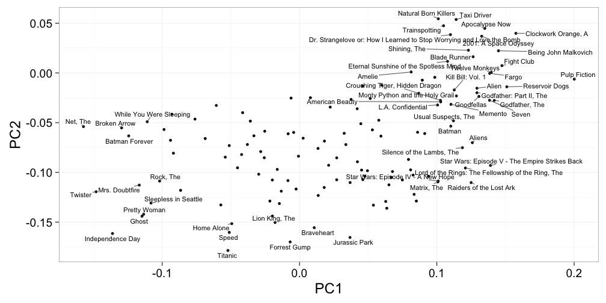

### PCA

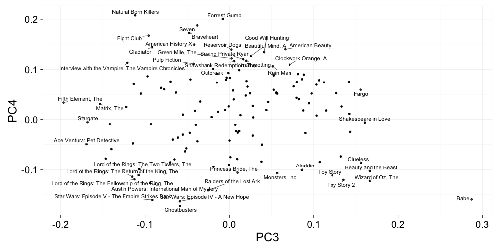

### Improvement

| method | RMSE |
| --- | --- |
| Just the average | 1.0604 |
| Movie Effect Model | 0.9548 |
| Movie Effect Model Lambda=3 | 0.9545 |
| Movie and User Effect Model | 0.8683 |
| Matrix Decomposition | 0.8678 |